# Introdução

**Metodologia**  
Inicialmente, foi realizado o tratamento dos dados, seguido por uma análise exploratória, que incluiu o ajuste dos preços com base na inflação. Em seguida, foram aplicados os algoritmos de Regressão Linear e Floresta Aleatória para prever os preços dos veículos, utilizando variáveis selecionadas com base em análises de correlação.

**Resultados e Conclusões**  
Ao decorrer do estudo, foi possível extrair insights relevantes sobre o mercado de vendas de veículos no período analisado, com base nos dados disponíveis.

```python
import pandas as pd
import matplotlib.pyplot as plt
import seaborn as sns
from datetime import date
import cpi
import numpy as np
from scipy.stats import chi2_contingency
from scipy.stats import zscore
from sklearn.model_selection import train_test_split
from sklearn.preprocessing import OneHotEncoder, StandardScaler
from sklearn.compose import ColumnTransformer
from sklearn.pipeline import Pipeline
from sklearn.ensemble import RandomForestRegressor
from sklearn.linear_model import LinearRegression
from statsmodels.stats.stattools import durbin_watson
import statsmodels.api as sm
from sklearn.metrics import mean_squared_error, r2_score
from scipy.stats import shapiro
```

```python
df = pd.read_csv("car_prices.csv", delimiter=",")
df
```

|  | year | make | model | trim | body | transmission | vin | state | condition | odometer | color | interior | seller | mmr | sellingprice | saledate |
| --- | --- | --- | --- | --- | --- | --- | --- | --- | --- | --- | --- | --- | --- | --- | --- | --- |
| 0 | 2015 | Kia | Sorento | LX | SUV | automatic | 5xyktca69fg566472 | ca | 5.0 | 16639.0 | white | black | kia motors america inc | 20500.0 | 21500.0 | Tue Dec 16 2014 12:30:00 GMT-0800 (PST) |
| 1 | 2015 | Kia | Sorento | LX | SUV | automatic | 5xyktca69fg561319 | ca | 5.0 | 9393.0 | white | beige | kia motors america inc | 20800.0 | 21500.0 | Tue Dec 16 2014 12:30:00 GMT-0800 (PST) |
| 2 | 2014 | BMW | 3 Series | 328i SULEV | Sedan | automatic | wba3c1c51ek116351 | ca | 45.0 | 1331.0 | gray | black | financial services remarketing (lease) | 31900.0 | 30000.0 | Thu Jan 15 2015 04:30:00 GMT-0800 (PST) |
| 3 | 2015 | Volvo | S60 | T5 | Sedan | automatic | yv1612tb4f1310987 | ca | 41.0 | 14282.0 | white | black | volvo na rep/world omni | 27500.0 | 27750.0 | Thu Jan 29 2015 04:30:00 GMT-0800 (PST) |
| 4 | 2014 | BMW | 6 Series Gran Coupe | 650i | Sedan | automatic | wba6b2c57ed129731 | ca | 43.0 | 2641.0 | gray | black | financial services remarketing (lease) | 66000.0 | 67000.0 | Thu Dec 18 2014 12:30:00 GMT-0800 (PST) |
| ... | ... | ... | ... | ... | ... | ... | ... | ... | ... | ... | ... | ... | ... | ... | ... | ... |
| 558832 | 2015 | Kia | K900 | Luxury | Sedan | NaN | knalw4d4xf6019304 | in | 45.0 | 18255.0 | silver | black | avis corporation | 35300.0 | 33000.0 | Thu Jul 09 2015 07:00:00 GMT-0700 (PDT) |
| 558833 | 2012 | Ram | 2500 | Power Wagon | Crew Cab | automatic | 3c6td5et6cg112407 | wa | 5.0 | 54393.0 | white | black | i -5 uhlmann rv | 30200.0 | 30800.0 | Wed Jul 08 2015 09:30:00 GMT-0700 (PDT) |
| 558834 | 2012 | BMW | X5 | xDrive35d | SUV | automatic | 5uxzw0c58cl668465 | ca | 48.0 | 50561.0 | black | black | financial services remarketing (lease) | 29800.0 | 34000.0 | Wed Jul 08 2015 09:30:00 GMT-0700 (PDT) |
| 558835 | 2015 | Nissan | Altima | 2.5 S | sedan | automatic | 1n4al3ap0fc216050 | ga | 38.0 | 16658.0 | white | black | enterprise vehicle exchange / tra / rental / t... | 15100.0 | 11100.0 | Thu Jul 09 2015 06:45:00 GMT-0700 (PDT) |
| 558836 | 2014 | Ford | F-150 | XLT | SuperCrew | automatic | 1ftfw1et2eke87277 | ca | 34.0 | 15008.0 | gray | gray | ford motor credit company llc pd | 29600.0 | 26700.0 | Thu May 28 2015 05:30:00 GMT-0700 (PDT) |

558837 rows × 16 columns

```python
df.info()
```

```
<class 'pandas.core.frame.DataFrame'>
RangeIndex: 558837 entries, 0 to 558836
Data columns (total 16 columns):
 #   Column        Non-Null Count   Dtype
---  ------        --------------   -----
 0   year          558837 non-null  int64
 1   make          548536 non-null  object
 2   model         548438 non-null  object
 3   trim          548186 non-null  object
 4   body          545642 non-null  object
 5   transmission  493485 non-null  object
 6   vin           558833 non-null  object
 7   state         558837 non-null  object
 8   condition     547017 non-null  float64
 9   odometer      558743 non-null  float64
 10  color         558088 non-null  object
 11  interior      558088 non-null  object
 12  seller        558837 non-null  object
 13  mmr           558799 non-null  float64
 14  sellingprice  558825 non-null  float64
 15  saledate      558825 non-null  object
dtypes: float64(4), int64(1), object(11)
memory usage: 68.2+ MB
```

```python
df.describe()
```

|  | year | condition | odometer | mmr | sellingprice |
| --- | --- | --- | --- | --- | --- |
| count | 558837.000000 | 547017.000000 | 558743.000000 | 558799.000000 | 558825.000000 |
| mean | 2010.038927 | 30.672365 | 68320.017767 | 13769.377495 | 13611.358810 |
| std | 3.966864 | 13.402832 | 53398.542821 | 9679.967174 | 9749.501628 |
| min | 1982.000000 | 1.000000 | 1.000000 | 25.000000 | 1.000000 |
| 25% | 2007.000000 | 23.000000 | 28371.000000 | 7100.000000 | 6900.000000 |
| 50% | 2012.000000 | 35.000000 | 52254.000000 | 12250.000000 | 12100.000000 |
| 75% | 2013.000000 | 42.000000 | 99109.000000 | 18300.000000 | 18200.000000 |
| max | 2015.000000 | 49.000000 | 999999.000000 | 182000.000000 | 230000.000000 |

```python
df.isnull().sum()
```

```
year                0
make            10301
model           10399
trim            10651
body            13195
transmission    65352
vin                 4
state               0
condition       11820
odometer           94
color             749
interior          749
seller              0
mmr                38
sellingprice       12
saledate           12
dtype: int64
```

```python
df['condition'] = pd.to_numeric(df['condition'], errors='coerce')
def replace_condition(row):
    if row['condition'] == 50:
      return 'Excellent'
    elif (row['condition'] <= 49.0) and (row['condition'] >= 40.0):
        return 'Good'
    elif (row['condition'] <= 39.0) and (row['condition'] >= 30.0):
        return 'Fair'
    elif (row['condition'] <= 29.0) and (row['condition'] >= 20.0):
        return 'Poor'
    elif row['condition'] < 20.0:
        return 'Needs major maintenance'
    else :
        return row['condition']
```

```python
df['condition_cat'] = df.apply(replace_condition, axis=1)
```

```python
df.fillna({"condition_cat":"No condition"}, inplace=True)
```

```python
df['condition_cat']
```

```
0         Needs major maintenance
1         Needs major maintenance
2                            Good
3                            Good
4                            Good
                   ...
558832                       Good
558833    Needs major maintenance
558834                       Good
558835                       Fair
558836                       Fair
Name: condition_cat, Length: 558837, dtype: object
```

```python
for col in ['make', 'model', 'trim', 'body', 'transmission', 'color', 'interior']:
    df[col] = df[col].fillna(df[col].mode()[0])
for col in ['odometer', 'mmr', 'sellingprice', 'condition']:
    df[col] = df[col].fillna(df[col].median())
```

```python
df['sellingprice'] = pd.to_numeric(df['sellingprice'], errors='coerce')
def categorize_price(row):
    if row['sellingprice'] < 30000:
        return "Budget"
    elif 30000 <= row['sellingprice'] < 50000:
        return "Mid-Range"
    else:
        return "Luxury"
```

```python
df['sellingprice_cat'] = df.apply(categorize_price, axis=1)
```

```python
df.isnull().sum()
```

```
year                 0
make                 0
model                0
trim                 0
body                 0
transmission         0
vin                  4
state                0
condition            0
odometer             0
color                0
interior             0
seller               0
mmr                  0
sellingprice         0
saledate            12
condition_cat        0
sellingprice_cat     0
dtype: int64
```

```python
df.duplicated().sum()
```

```
0
```

```python
for col in ['make', 'model', 'trim', 'body', 'transmission', 'state', 'color', 'interior', 'seller']:
    df[col] = df[col].astype('str').str.capitalize()
df['transmission'] = df['transmission'].str.replace('Sedan', 'Automatic')
```

```python
df.drop(columns=['vin'], inplace=True)
```

# Análise univariada

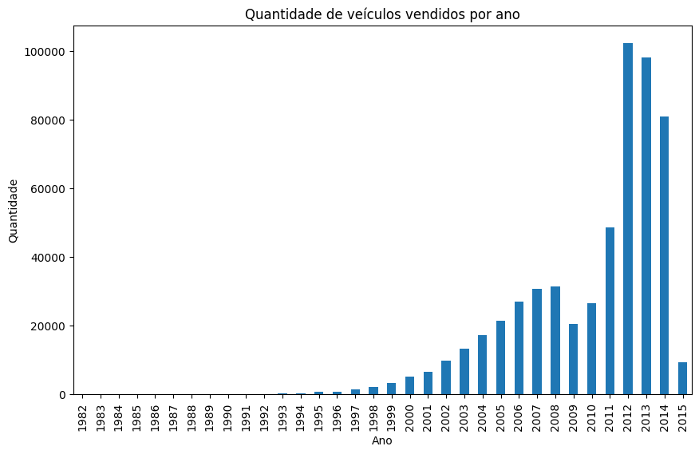

```python
agrupado = df.groupby('year').size().sort_index()
agrupado.plot(kind="bar", figsize=(10,6))
plt.title("Quantidade de veículos vendidos por ano")
plt.xlabel("Ano")
plt.ylabel("Quantidade")
```

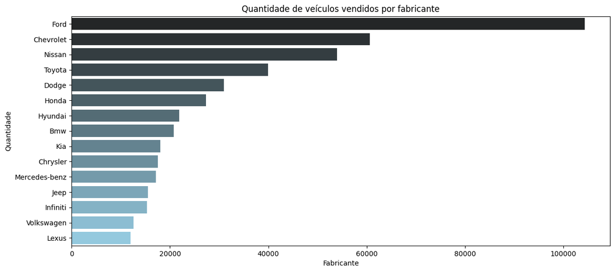

```python
agrupado = df.groupby('make').size().nlargest(15).reset_index()
plt.figure(figsize=(14, 6))
sns.barplot(x=0, y='make', data=agrupado, palette="dark:skyblue")
plt.title("Quantidade de veículos vendidos por fabricante")
plt.xlabel("Fabricante")
plt.ylabel("Quantidade")
```

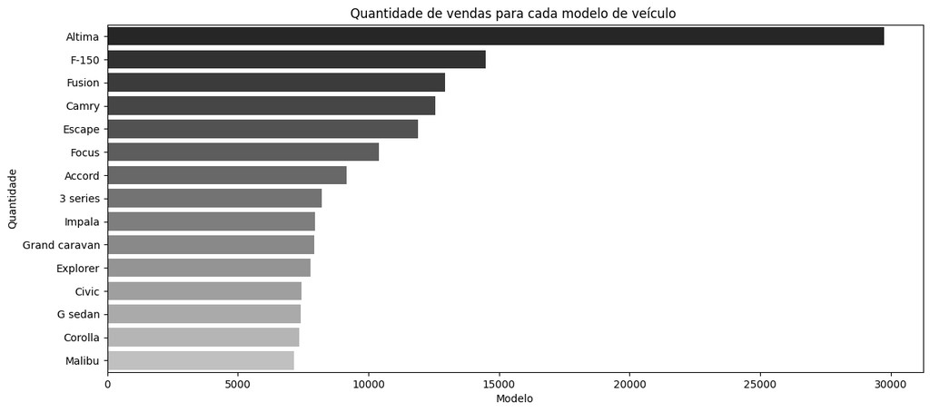

```python
agrupado = df.groupby('model').size().nlargest(15).reset_index()
plt.figure(figsize=(14, 6))
sns.barplot(x=0, y='model', data=agrupado, palette="dark:silver")
plt.title("Quantidade de vendas para cada modelo de veículo ")
plt.xlabel("Modelo")
plt.ylabel("Quantidade")
```

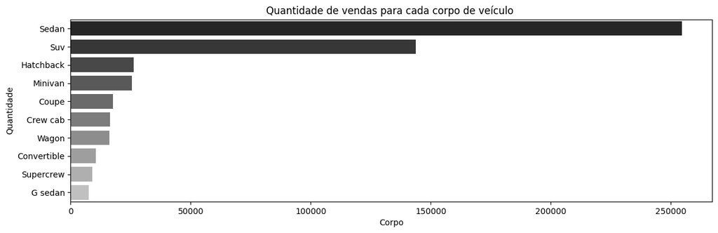

```python
agrupado = df.groupby('body').size().nlargest(10).reset_index()
plt.figure(figsize=(14, 4))
sns.barplot(x=0, y='body', data=agrupado, palette="dark:silver")
plt.title("Quantidade de vendas para cada corpo de veículo ")
plt.xlabel("Corpo")
plt.ylabel("Quantidade")
```

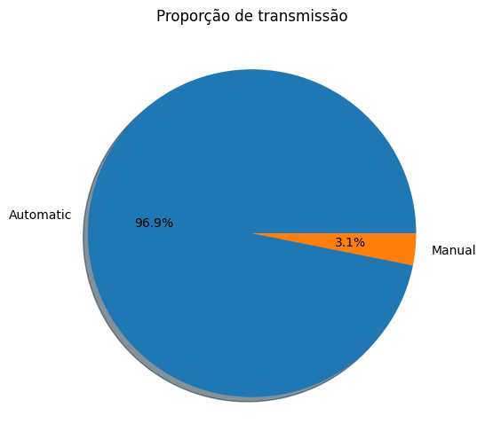

```python
plt.figure(figsize=(6, 6))
values = df['transmission'].value_counts()
plt.pie(values, labels=values.index, autopct='%.1f%%', shadow=True)
plt.title('Proporção de transmissão')
plt.show()
```

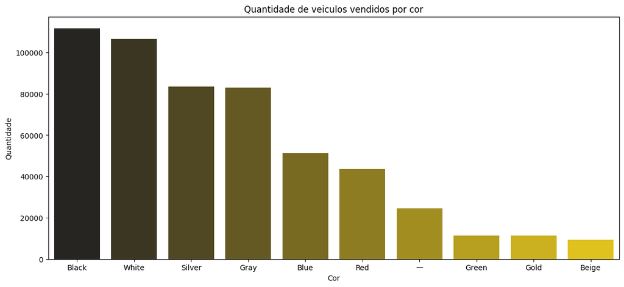

```python
agrupado = df.groupby('color').size().nlargest(10).reset_index()
plt.figure(figsize=(14, 6))
sns.barplot(x='color', y=0, data=agrupado, palette="dark:gold")
plt.title("Quantidade de veiculos vendidos por cor")
plt.xlabel("Cor")
plt.ylabel("Quantidade")
```

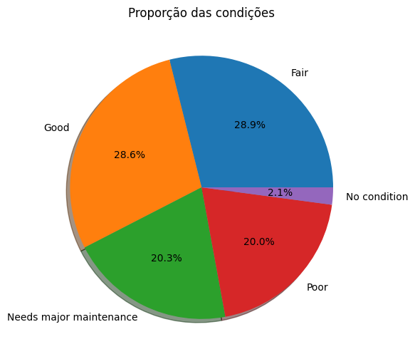

```python
plt.figure(figsize=(6, 6))
values = df['condition_cat'].value_counts()
plt.pie(values, labels=values.index, autopct='%.1f%%', shadow=True)
plt.title('Proporção das condições')
plt.show()
```

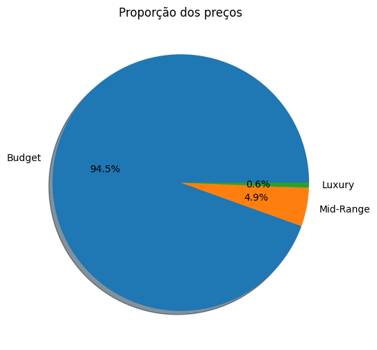

```python
plt.figure(figsize=(6, 6))
values = df['sellingprice_cat'].value_counts()
plt.pie(values, labels=values.index, autopct='%.1f%%', shadow=True)
plt.title('Proporção dos preços')
plt.show()
```

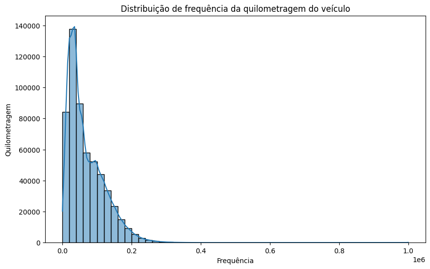

```python
plt.figure(figsize=(10,6))
sns.histplot(df['odometer'], bins=50, kde=True)
plt.title("Distribuição de frequência da quilometragem do veículo")
plt.xlabel("Frequência")
plt.ylabel("Quilometragem")
```

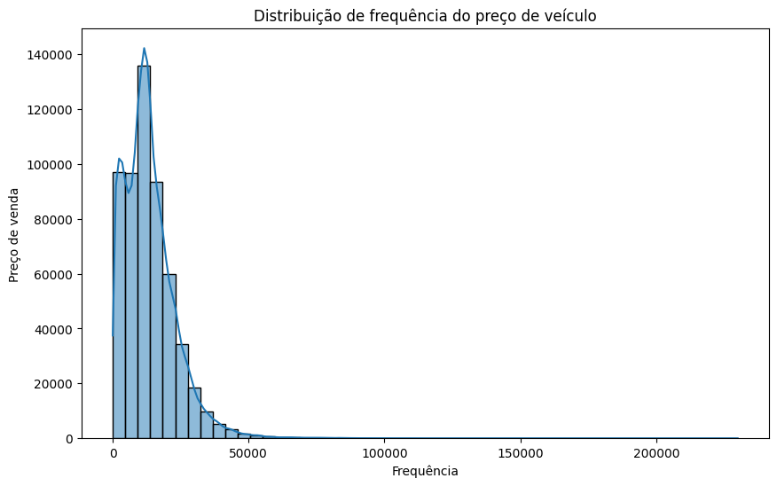

```python
plt.figure(figsize=(10,6))
sns.histplot(df['sellingprice'], bins=50, kde=True)
plt.title("Distribuição de frequência do preço de veículo")
plt.xlabel("Frequência")
plt.ylabel("Preço de venda")
```

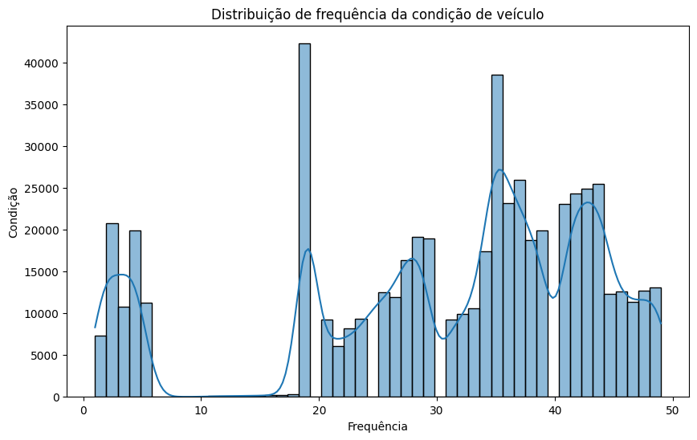

```python
plt.figure(figsize=(10,6))
sns.histplot(df['condition'], bins=50, kde=True)
plt.title("Distribuição de frequência da condição de veículo")
plt.xlabel("Frequência")
plt.ylabel("Condição")
```

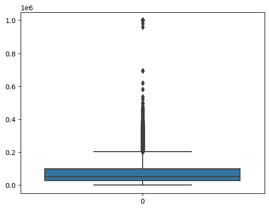

```python
sns.boxplot(data=df['odometer'])
```

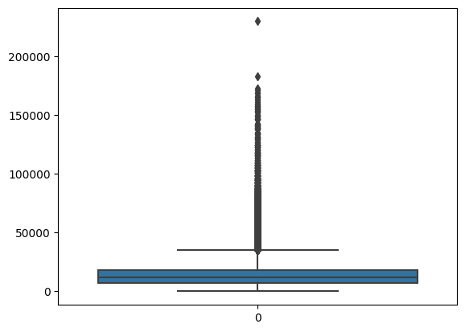

```python
sns.boxplot(data=[df['sellingprice']])
```

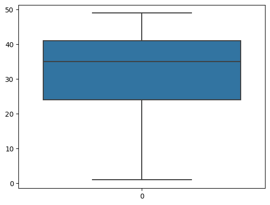

```python
sns.boxplot(data=df['condition'])
```

## Tratamento do preço corrigindo pela inflação

```python
cpi_years = {}
for year in df['year'].unique():
    cpi_years[year] = cpi.get(year)
```

```python
cpi_most_recent = cpi.get(date(2025, 1, 1))
adjust_factors = {year: cpi_most_recent/cpi_years[year] for year in cpi_years}

df['adjust_factor'] = df['year'].map(adjust_factors)
df['adjusted_price'] = df['sellingprice'] * df['adjust_factor']
```

```python
df['adjusted_mmr'] = df['mmr'] * df['adjust_factor']
df['diff_price_mmr'] = df['adjusted_price'] - df['adjusted_mmr']
df.drop(columns=['adjust_factor'], inplace=True)
```

# Analise multivariada

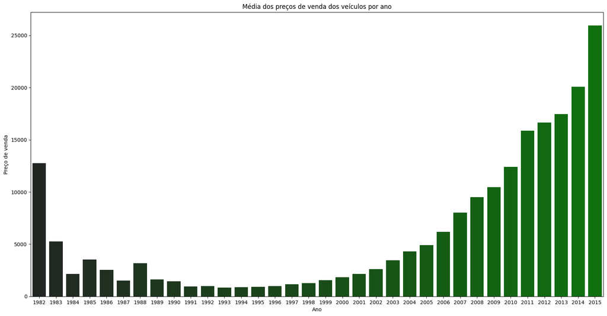

```python
agrupado = df.groupby('year')['sellingprice'].mean().reset_index()
plt.figure(figsize=(20, 10))
sns.barplot(x='year', y='sellingprice', data=agrupado, palette="dark:green")
plt.title("Média dos preços de venda dos veículos por ano")
plt.xlabel("Ano")
plt.ylabel("Preço de venda")
```

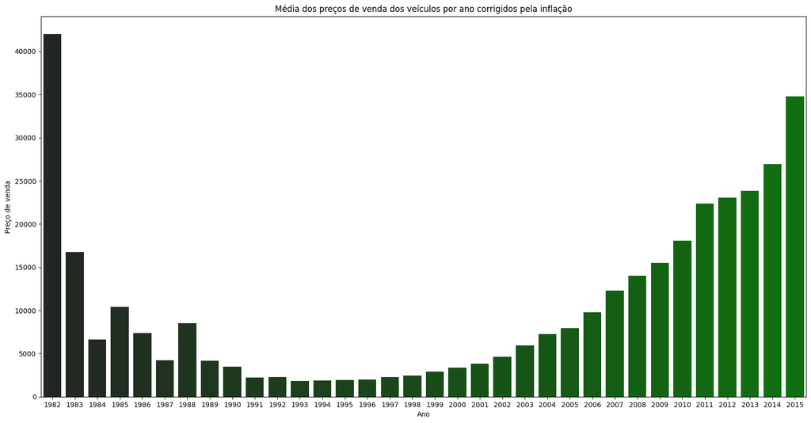

```python
agrupado = df.groupby('year')['adjusted_price'].mean().reset_index()
plt.figure(figsize=(20, 10))
sns.barplot(x='year', y='adjusted_price', data=agrupado, palette="dark:green")
plt.title("Média dos preços de venda dos veículos por ano corrigidos pela inflação")
plt.xlabel("Ano")
plt.ylabel("Preço de venda")
```

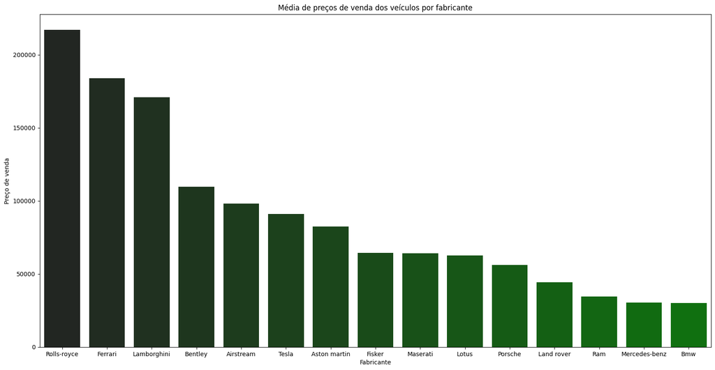

```python
agrupado = df.groupby('make')['adjusted_price'].mean().nlargest(15).reset_index()
plt.figure(figsize=(20, 10))
sns.barplot(x='make', y='adjusted_price', data=agrupado, palette="dark:green")
plt.title("Média de preços de venda dos veículos por fabricante")
plt.xlabel("Fabricante")
plt.ylabel("Preço de venda")
```

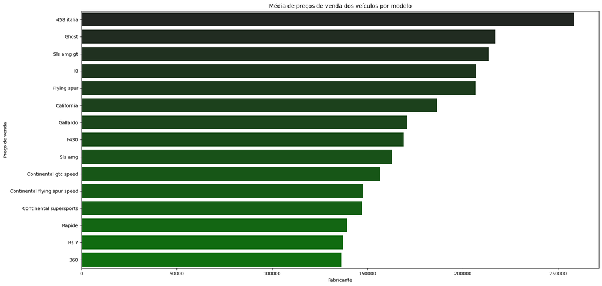

```python
agrupado = df.groupby('model')['adjusted_price'].mean().nlargest(15).reset_index()
plt.figure(figsize=(20, 10))
sns.barplot(x='adjusted_price', y='model', data=agrupado, palette="dark:green")
plt.title("Média de preços de venda dos veículos por modelo")
plt.xlabel("Fabricante")
plt.ylabel("Preço de venda")
```

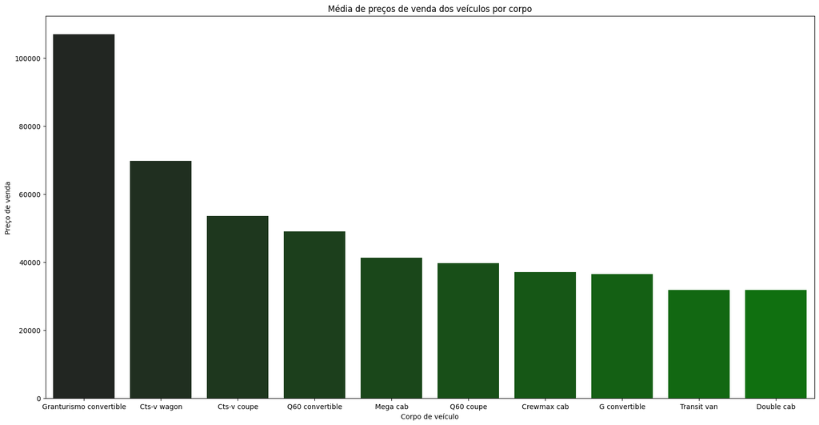

```python
agrupado = df.groupby('body')['adjusted_price'].mean().nlargest(10).reset_index()
plt.figure(figsize=(20, 10))
sns.barplot(x='body', y='adjusted_price', data=agrupado, palette="dark:green")
plt.title("Média de preços de venda dos veículos por corpo")
plt.xlabel("Corpo de veículo")
plt.ylabel("Preço de venda")
```

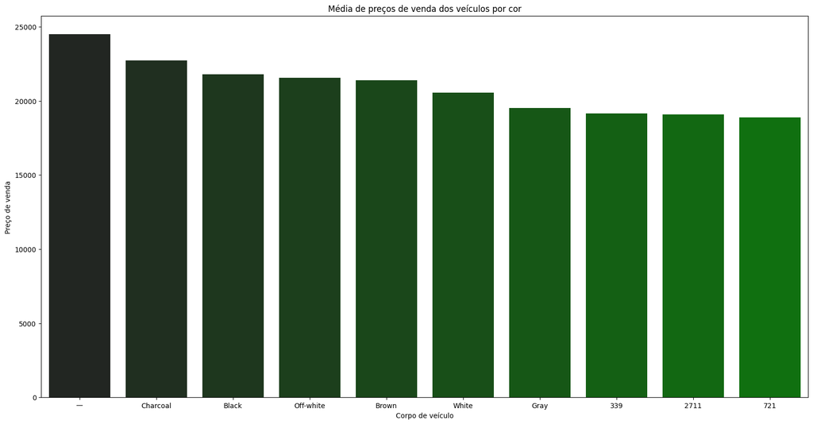

```python
agrupado = df.groupby('color')['adjusted_price'].mean().nlargest(10).reset_index()
plt.figure(figsize=(20, 10))
sns.barplot(x='color', y='adjusted_price', data=agrupado, palette="dark:green")
plt.title("Média de preços de venda dos veículos por cor")
plt.xlabel("Corpo de veículo")
plt.ylabel("Preço de venda")
```

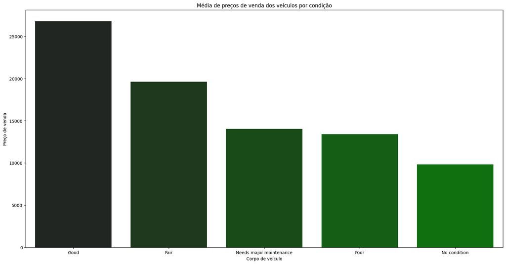

```python
agrupado = df.groupby('condition_cat')['adjusted_price'].mean().nlargest(10).reset_index()
plt.figure(figsize=(20, 10))
sns.barplot(x='condition_cat', y='adjusted_price', data=agrupado, palette="dark:green")
plt.title("Média de preços de venda dos veículos por condição")
plt.xlabel("Corpo de veículo")
plt.ylabel("Preço de venda")
```

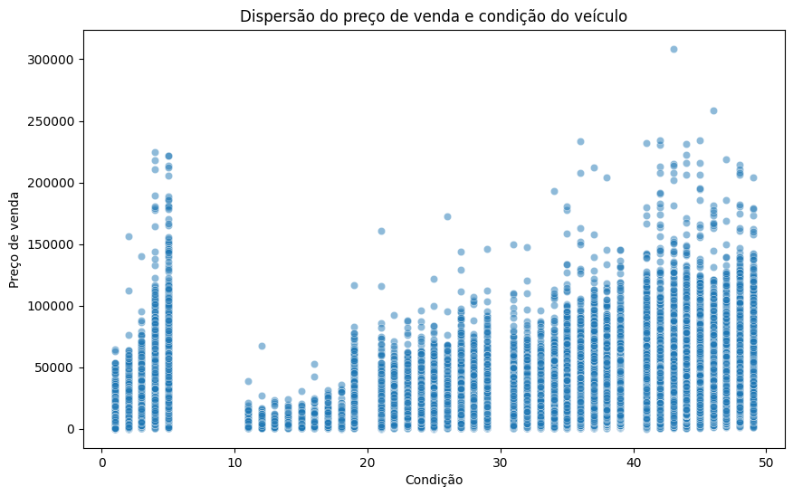

```python
plt.figure(figsize=(10,6))
sns.scatterplot(x = "condition", y = "adjusted_price", data=df, alpha=0.5)
plt.title("Dispersão do preço de venda e condição do veículo")
plt.xlabel("Condição")
plt.ylabel("Preço de venda")
```

# Análise das correlações

```python
df['odometer'] = pd.to_numeric(df['odometer'], errors='coerce')
df['adjusted_mmr'] = pd.to_numeric(df['adjusted_mmr'], errors='coerce')
df['diff_price_mmr'] = pd.to_numeric(df['diff_price_mmr'], errors='coerce')
```

Como as variaveis não seguem uma distribuição normal e não tem uma relação linear o teste de Spearman será o mais adequado.

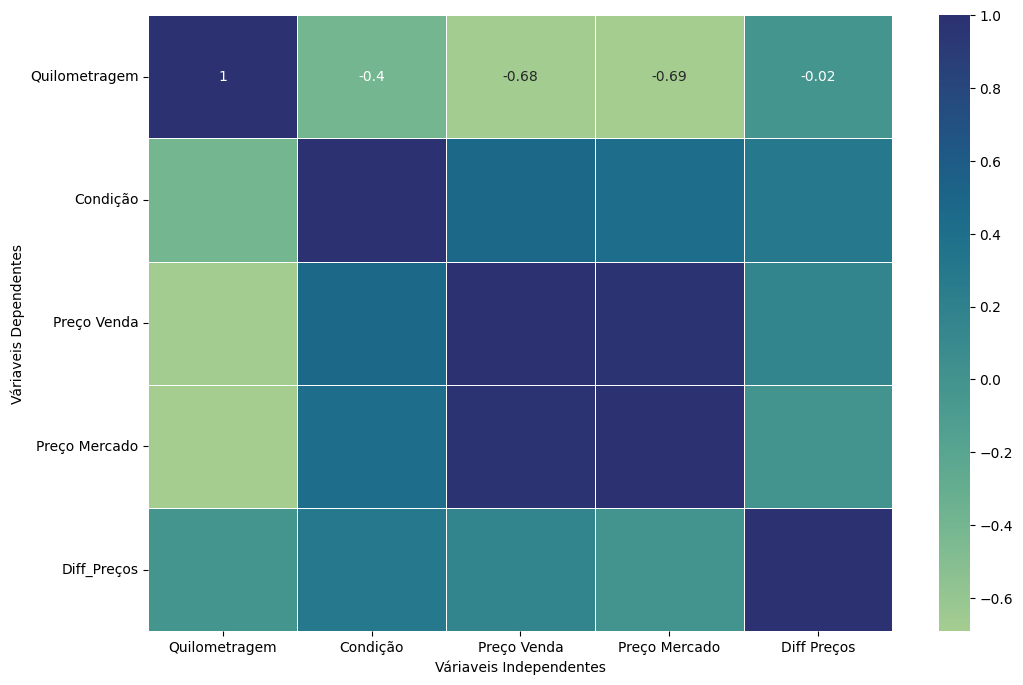

```python
plt.figure(figsize=(12,8))
matriz_corr = df[['odometer', 'condition', 'adjusted_price', 'adjusted_mmr', 'diff_price_mmr']].corr(method="spearman")
heatmap = sns.heatmap(matriz_corr, annot=True, cmap="crest", linewidths=0.5)
heatmap.set_xlabel("Váriaveis Independentes")
heatmap.set_ylabel("Váriaveis Dependentes")
heatmap.set_xticklabels(['Quilometragem', 'Condição', 'Preço Venda', 'Preço Mercado', 'Diff Preços'], rotation=0)
heatmap.set_yticklabels(['Quilometragem', 'Condição', 'Preço Venda', 'Preço Mercado', 'Diff_Preços'], rotation=0)
plt.show()
```

```python
matriz_corr
```

|  | odometer | condition | adjusted_price | adjusted_mmr | diff_price_mmr |
| --- | --- | --- | --- | --- | --- |
| odometer | 1.000000 | -0.398661 | -0.675960 | -0.691273 | -0.019781 |
| condition | -0.398661 | 1.000000 | 0.468245 | 0.413022 | 0.299423 |
| adjusted_price | -0.675960 | 0.468245 | 1.000000 | 0.976309 | 0.171494 |
| adjusted_mmr | -0.691273 | 0.413022 | 0.976309 | 1.000000 | -0.001455 |
| diff_price_mmr | -0.019781 | 0.299423 | 0.171494 | -0.001455 | 1.000000 |

## Interpretação

A quilometragem tem uma correlação negativa fraca com a condição do veículo e moderada negativa com os preços. Isso significa que quando a quilometragem é maior os preços tendem a ser menores, considerando o tipo de correlação é plausível afirmar que existem outros fatores que interferem no preço como o modelo, a propria condição, a fabricante, etc. Em relação a condição e quilometragem, serviços de manutenção podem manter a boa condição do veiculo mesmo com uma quilometragem consideravel, além da qualidade das peças e do tipo de via que o veículo trafega. Nos preços a condição tem uma correlação fraca positiva, ou seja, a boa condição do veículo não é tão determinante no seu preço. A diferença do preço de venda com o de mercado não apresentou nenhuma correlação significativa com as outras váriaveis.

## Correlação das váriaveis categóricas

O teste Cramér's V consegue medir a associação entre dois atributos a partir de valores de 0 a 1 em que 0 indica ausência de correlação e 1 a correlação mais forte.

```python
def cramers_v(x, y):
    confusion_matrix = pd.crosstab(x, y)
    chi2 = chi2_contingency(confusion_matrix)[0]
    n = confusion_matrix.sum().sum()
    phi2 = chi2 / n
    r, k = confusion_matrix.shape
    phi2corr = max(0, phi2 - ((k-1)*(r-1))/(n-1))
    rcorr = r - ((r-1)**2)/(n-1)
    kcorr = k - ((k-1)**2)/(n-1)
    return np.sqrt(phi2corr / min((kcorr-1), (rcorr-1)))
```

```python
def calculate_cramers_v_matrix(df, columns, target_var):
    results = []
    for col in columns:
        if col != target_var and df[col].dtype == 'object':
            v = cramers_v(df[target_var], df[col])
            results.append({'Variável': col, "Cramér's V": v})
    return pd.DataFrame(results).sort_values("Cramér's V", ascending=False)
```

```python
columns = ["make", "model", "transmission", "seller", "sellingprice_cat", "condition_cat"]
for col in columns:
    print(col)
    print()
    corr_matriz = calculate_cramers_v_matrix(df, columns, col)
    print(corr_matriz)
```

```
make

           Variável  Cramér's V
0             model    0.910676
2            seller    0.419697
3  sellingprice_cat    0.322580
1      transmission    0.198649
4     condition_cat    0.113915
model

           Variável  Cramér's V
0              make    0.910676
3  sellingprice_cat    0.545923
1      transmission    0.392811
2            seller    0.209982
4     condition_cat    0.195054
transmission

           Variável  Cramér's V
1             model    0.392811
2            seller    0.205007
0              make    0.198649
4     condition_cat    0.025440
3  sellingprice_cat    0.012970
seller

           Variável  Cramér's V
4     condition_cat    0.496420
0              make    0.419697
3  sellingprice_cat    0.388210
1             model    0.209982
2      transmission    0.205007
sellingprice_cat

        Variável  Cramér's V
1          model    0.545923
3         seller    0.388210
0           make    0.322580
4  condition_cat    0.119045
2   transmission    0.012970
condition_cat

           Variável  Cramér's V
3            seller    0.496420
1             model    0.195054
4  sellingprice_cat    0.119045
0              make    0.113915
2      transmission    0.025440
```

A entidade que fez a venda do veículo tem uma correlação relativamente forte com as condições de veículo enquanto modelo e fabricante possuem correlações fracas e a da transmissão é insignificante. Desta forma, as entidades tendem a vender os veículos com certa condição independentemente do modelo e do fabricante. Já a categoria de preços apresenta uma correlação relativamente forte com o modelo e moderada com a entidade e fabricante. Outra correlação importante é entre marca e modelo que é quase uma associação perfeita, ou seja, os modelos estão fortemente associados com sua marca. Isso é um problema para o modelo de regressão linear no que tange a multicolinearidade. Para resolver esse problema foi realizado o agrupamento de veículos como marca_modelo.

```python
df['make_model'] = df['make'].str.lower() + '_' + df['model'].str.lower()
```

# Modelos de regressão na previsão de preços

## Tratamento de outliers

```python
df['adjusted_price_z'] = zscore(df['adjusted_price'])
df['odometer_z'] = zscore(df['odometer'])
```

```python
df_clean = df[(abs(df['adjusted_price_z']) <= 3.0) & (abs(df['odometer_z']) <= 3.0)]
df.drop(columns=['adjusted_price_z', 'odometer_z'], inplace=True)
```

```python
df_clean.drop(columns=['adjusted_price_z', 'odometer_z'], inplace=True)
```

## Modelagem

A seleção das váriaveis que serão utilizadas no treinamento foram feitas considerando a análise das correlações. A partir da análise, foi constatado que nenhuma das váriaveis independentes apresentam multicolinearidade que é um dos pressupostos para o modelo de regressão linear. As váriavel transmissão teve uma correlação insignificante com os preços por isso ela foi descartada. Modelo e fabricante foram substituídos por make_model para evitar a multicolinearidade.

```python
df_model = df_clean.sample(n=50000)
X = df_model.drop(columns=['adjusted_price', 'sellingprice', 'model', 'make', 'trim', 'transmission', 'condition_cat', 'sellingprice_cat', 'diff_price_mmr', 'saledate', 'mmr', 'adjusted_mmr'], axis=1)
y = df_model['adjusted_price']

colunas_numericas = X.select_dtypes(include=['int64', 'float64']).columns.tolist()
colunas_categoricas = X.select_dtypes(include=['object', 'category']).columns.tolist()

preprocessador = ColumnTransformer(transformers=[
    ('num', StandardScaler(), colunas_numericas),
    ('cat', OneHotEncoder(handle_unknown='ignore'), colunas_categoricas)
])
```

### Regressão Linear

```python
X_train, X_test, y_train, y_test = train_test_split(X, y, test_size=0.2, random_state=42)

RegressaoLinear = Pipeline(steps=[
    ('preprocessador', preprocessador),
    ('regressor', LinearRegression())
])

X_train, X_test, y_train, y_test = train_test_split(X, y, test_size=0.2, random_state=42)

RegressaoLinear.fit(X_train, y_train)

y_pred = RegressaoLinear.predict(X_test)

print("MSE:", mean_squared_error(y_test, y_pred))
print("R²:", r2_score(y_test, y_pred))
```

```
MSE: 20161631.166363746
R²: 0.8463186183537745
```

O MSE e o $R^2$ apresentaram bons resultados. Para o MSE de 20 milhões o erro médio é em termos práticos de 4 mil dolares.

### Presupostos do modelo de regressão linear

```python
fitted_values = RegressaoLinear.predict(X_train)
residuos = y_train - fitted_values
```

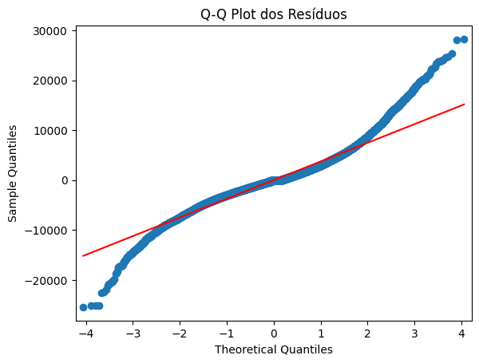

```python
sm.qqplot(residuos, line='s')
plt.title('Q-Q Plot dos Resíduos')
plt.show()
```

```python
_, p_value = shapiro(residuos)
print(f"Shapiro-Wilk p-value: {p_value}")
if p_value > 0.05:
    print("Resíduos parecem normais (não rejeitamos H0)")
else:
    print("Resíduos não parecem normais (rejeitamos H0)")
```

```
Shapiro-Wilk p-value: 9.748537377075531e-77
Resíduos não parecem normais (rejeitamos H0)
```

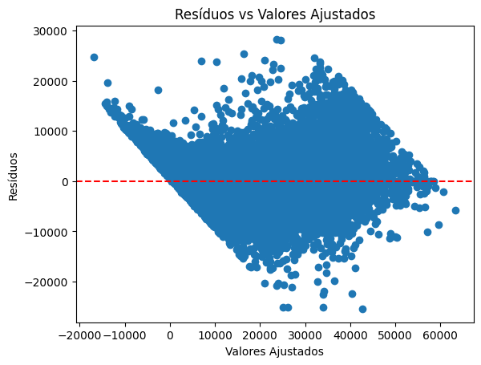

```python
plt.scatter(fitted_values, residuos)
plt.axhline(y=0, color='r', linestyle='--')
plt.xlabel('Valores Ajustados')
plt.ylabel('Resíduos')
plt.title('Resíduos vs Valores Ajustados')
plt.show()
```

```python
from statsmodels.stats.stattools import durbin_watson

dw = durbin_watson(residuos)
print(f"Estatística Durbin-Watson: {dw}")
if 1.5 < dw < 2.5:
    print("Pouca evidência de autocorrelação")
else:
    print("Possível autocorrelação nos resíduos")
```

```
Estatística Durbin-Watson: 2.009132516444934
Pouca evidência de autocorrelação
```

### Random Forest

```python
RandomForest = Pipeline(steps=[
    ('preprocessador', preprocessador),
    ('regressor', RandomForestRegressor(n_estimators=20, random_state=42))
])

X_train, X_test, y_train, y_test = train_test_split(X, y, test_size=0.2, random_state=42)

RandomForest.fit(X_train, y_train)

y_pred = RandomForest.predict(X_test)
print("MSE:", mean_squared_error(y_test, y_pred))
print("R²:", r2_score(y_test, y_pred))
```

```
MSE: 19502828.231132295
R²: 0.8513403224254108
```